# Prosper Loan Data Analysis by Jessica Vargas

## More explorations

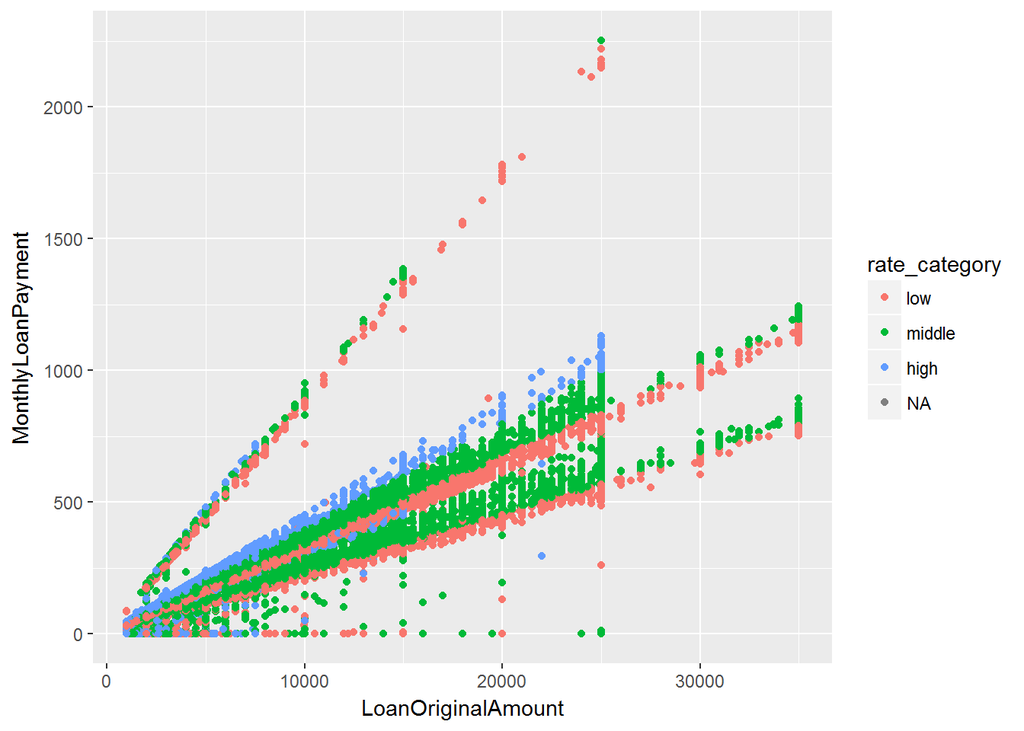

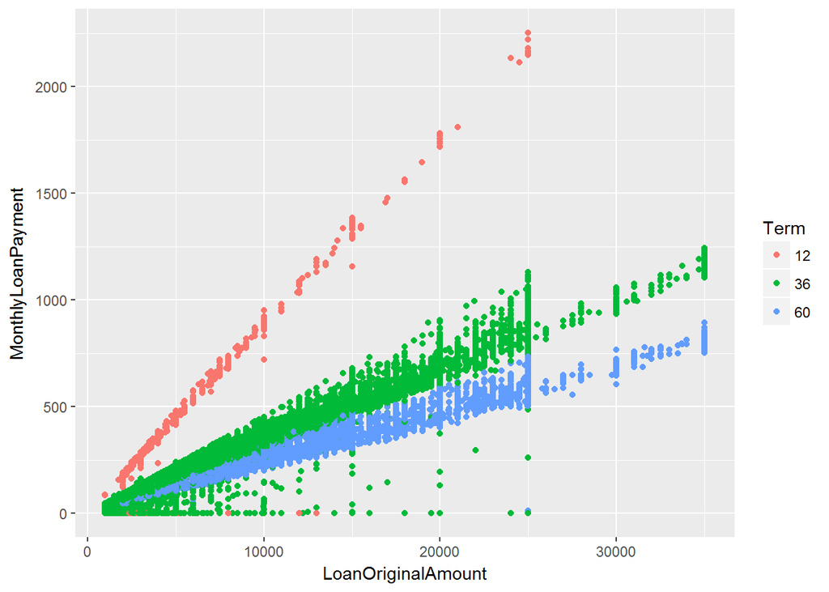

This plot shows monthly loan payments against original loan amounts. The colors represent the different rate category bins. I noticed that there are no high interest loans with original loan amounts greater than 25,000 and no 12 month loans above 25,000.

## Table aggregations

```
## [1] "Median LoanOriginal Amount by rate category and term"
```

```
##   rate_category Term LoanOriginalAmount MonthlyLoanPayment
## 1           low   12             3500.0            299.610
## 2        middle   12             3000.0            275.940
## 3          high   12             3500.0            335.530
## 4           low   36             7500.0            245.500
## 5        middle   36             6000.0            219.910
## 6          high   36             4000.0            166.540
## 7           low   60            15000.0            329.060
## 8        middle   60            13000.0            323.325
## 9          high   60             6285.5            194.595
```

```
## [1] "Max LoanOriginal Amount by rate category and term"
```

```
##   rate_category Term LoanOriginalAmount
## 1           low   12              25000
## 2        middle   12              25000
## 3          high   12               7500
## 4           low   36              35000
## 5        middle   36              35000
## 6          high   36              25000
## 7           low   60              35000
## 8        middle   60              35000
## 9          high   60              15000
```

Here I aggregated the median loan original amount and monthly loan payment by loan term and borrower rate category. Borrowers with higher tend to have lower amounts than borrowers with loans with higher interest rates except when they have 12 month term loans.The original loan amount is the same, but the monthly loan payment is higher due to higher interest.

I also wanted to see what the max loan amounts were by rate and term. Again, borrowers with loans with higher rates have much lower original loan amount.

## Other plots

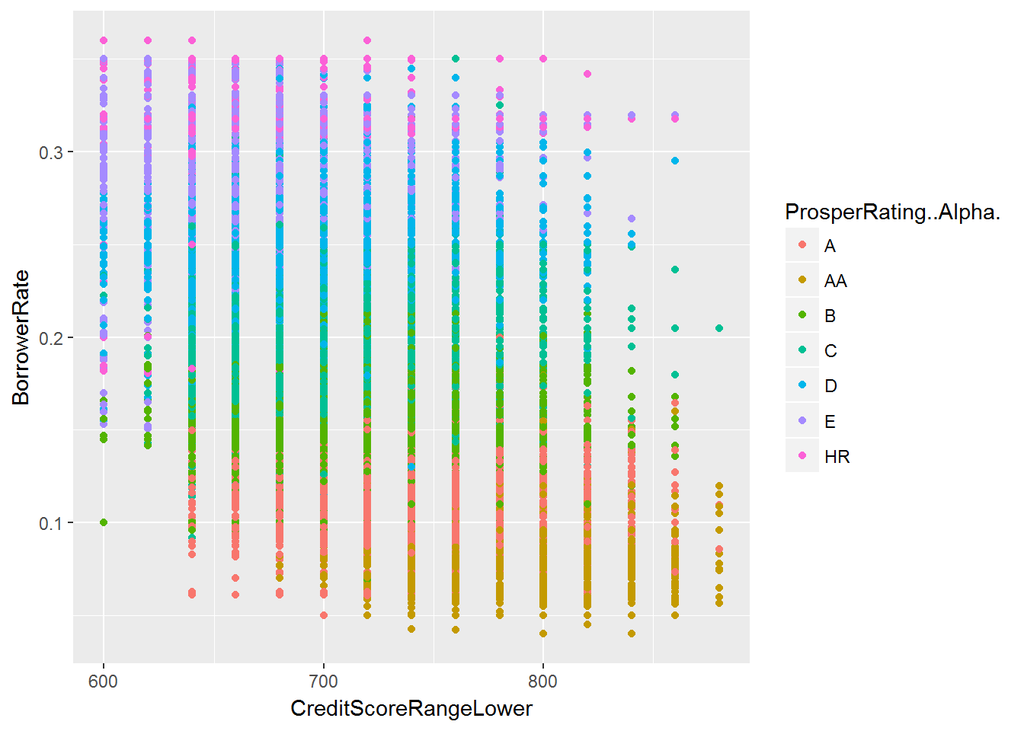

There doesn’t seem to be a clear relationship between credit score and interest rate as I’d assumed, but we can see from this graph that borrowers with lower ProsperRatings generally have higher interest rates. Those with higher ratings also tend to have higher credit scores. There must be several other factors that are used to calculate prosper rating score.

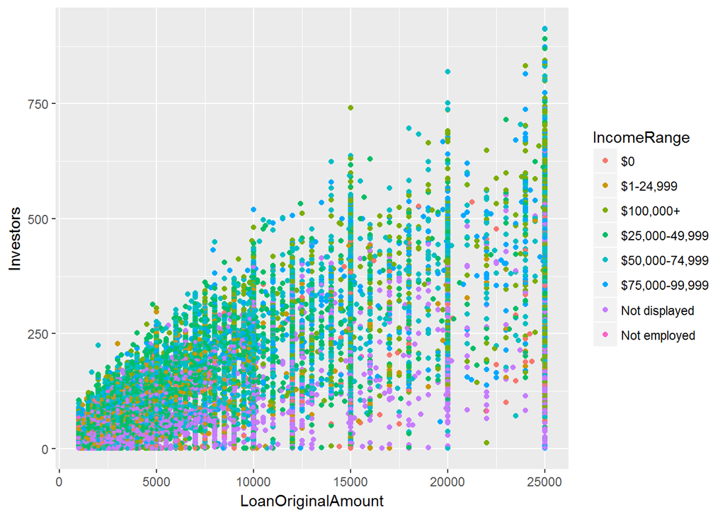

The larger the loan amount the, more number of investors you have, however, loans where borrower’s income information was missing or not available had a much lower number of investors.

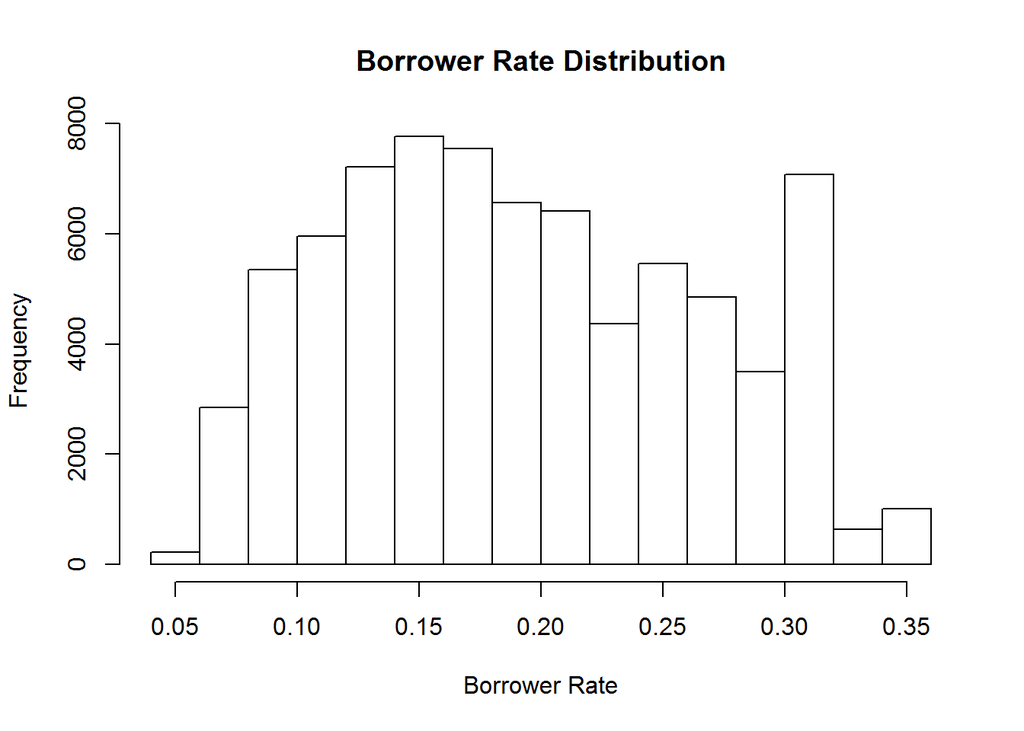

## Multiple Linear Regression Model 2

#### Model 2 Results Summary

[figure not shown]

Very small p-value and strong r-squared value (0.92) indicates a strong association between borrower rates and all the variables included in the model.

### Model Diagnostics

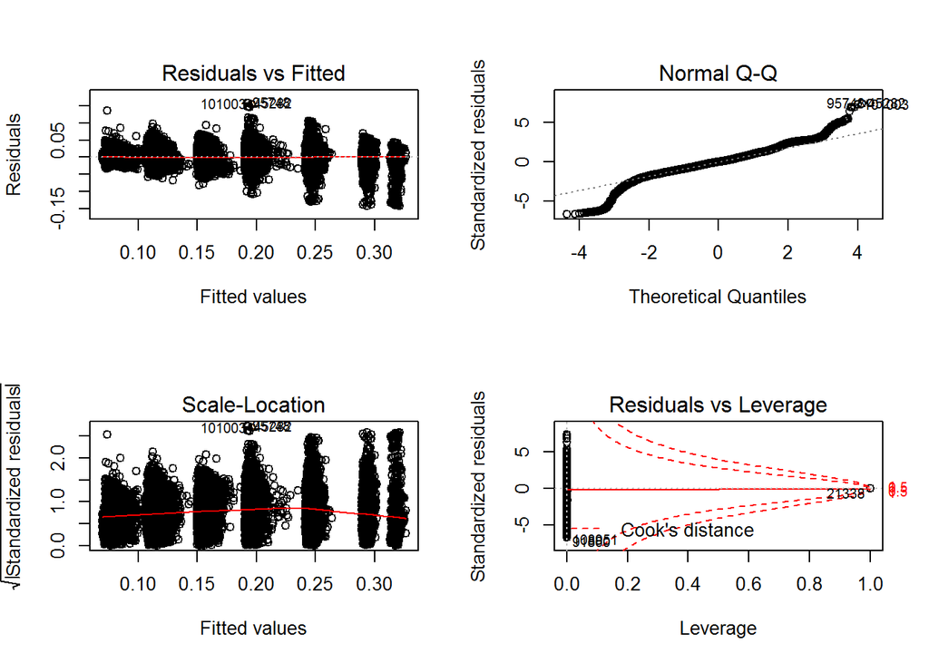

Here we have some dianostics graphs to assess whether or not this model violates any linear regression assumptions.

# Multivariate Analysis

### Talk about some of the relationships you observed in this part of the investigation. Were there features that strengthened each other in terms of

looking at your feature(s) of interest?

Borrowers with higher credit scores and Prosper Scores get bigger loans with lower interest rates. I also noticed that the larger the loan amount the, more number of investors you have, however, loans where borrower’s income information was missing or not available had a much lower number of investors. These borrowers probably seem riskier.

### Were there any interesting or surprising interactions between features?

Honestly, there was nothing really surprising here. Most of the data validates what you would expect in the lending business. Riskier clients have weaker credit profiles.

### OPTIONAL: Did you create any models with your dataset? Discuss the strengths and limitations of your model.

I created a few models with my dataset trying to predict borrower rate. The issue with using borrower rate as the dependent variable in my linear regression model, was that although the the variable is contniuous, there were only around 400-500 distinct values. The rates tend to cluster around certain values such as 0.05 or 0.25. This was a problem with performing initial diagnostics. Although the residual v fitted plots showed clusters around certain values, the variance is constant.

# Final Plots and Summary

### Plot One

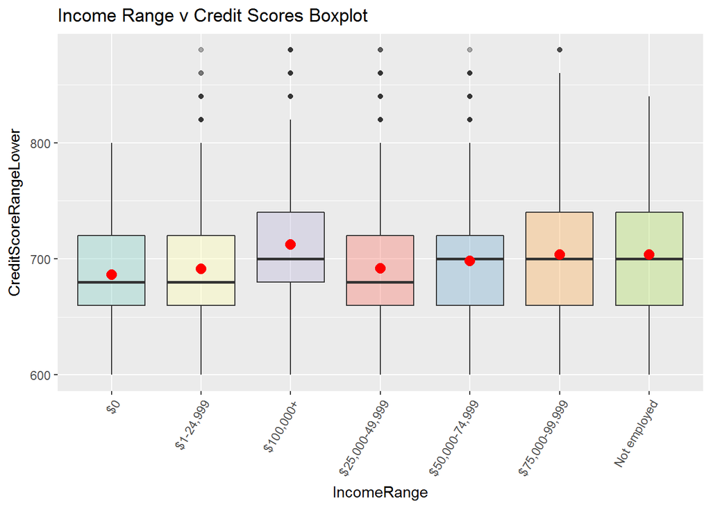

### Description One

This boxplot shows the the different ranges in credit scores by income range. This shows that borrowers with very income 100k+ have the high median and average credit scores. Those who reported 0 income and those in the next lowest income bracket have the lowest average/median credit scores. Oddly, borrowers that report “not employed” have a similar credit scores as the 75-99k income range borrowers.

### Plot Two

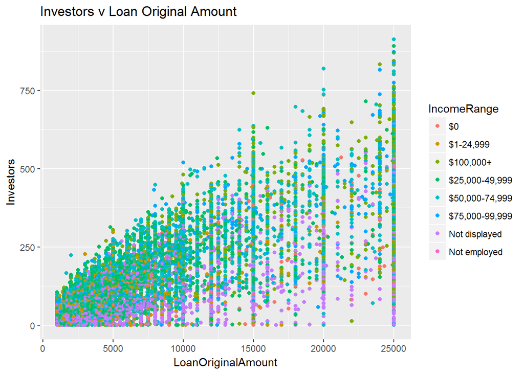

### Description Two

On this plot you can see that there is a positive association between the number of investors and original loan amount. Bigger loan sizes have a higher number of investors, however, loans where borrower’s income information was missing or not available had a much lower number of investors. Most lenders probably do not want to invest in a loan that seems risky.

### Plot Three

```
##                             low  middle    high
##
## Cancelled                -0.179   0.906  -1.119
## Chargedoff              -34.159  -7.317  43.829
## Completed                26.797 -18.492   0.221
## Current                   2.634  18.443 -28.910
## Defaulted               -19.561   1.572  16.870
## FinalPaymentInProgress    0.641  -1.733   1.848
## Past Due (>120 days)     -1.956  -0.059   1.996
## Past Due (1-15 days)     -9.925   0.770   8.600
## Past Due (16-30 days)    -6.075  -0.025   5.973
## Past Due (31-60 days)    -6.061  -1.275   7.744
## Past Due (61-90 days)    -6.651  -0.459   7.155
## Past Due (91-120 days)   -6.414  -1.301   8.125
```

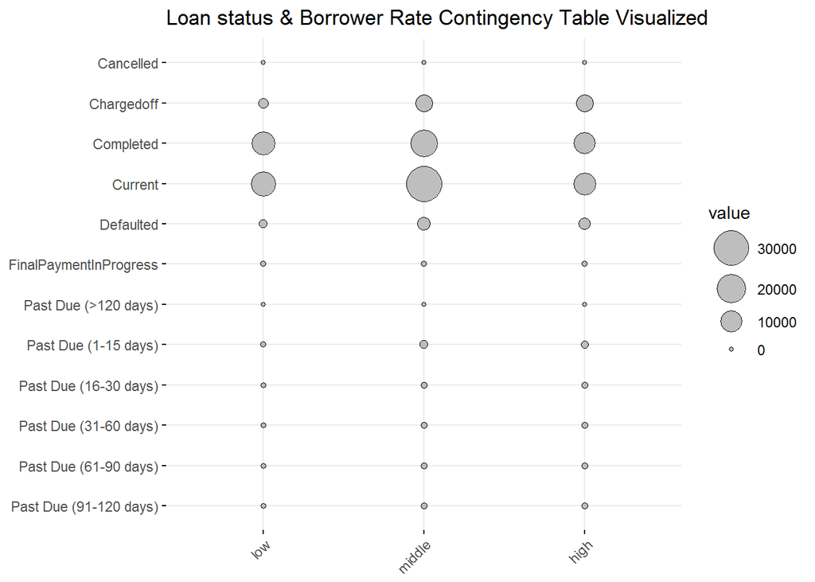

# Reflection

Although this dataset was not “large” according to today’s standrads, there were a ton of variables. For this project, I did not explore all variables, but only focused on a subset that related to credit worthiness and borrower information. The main issue I encountered with this dataset, was difference between data recorded before July 2009 and post 2009. There must have been a massive upgrade or change in their process prior to July 2009. I mainly focused on post July 2009data , because that is when they started using FICO credit scores and introduced ProsperRatings, an in house credit grade.

I focused on analyzing relationships between interest rates and a borrower’s credit worthiness. Some variables were multimodal and some had outliers that ended up being junk data. Some categorical variables were being treated as numerical, so I had to factor them before I could perform any analysis. When trying to build one of my linear regression models, I noticed that the using borrower rate as the dependent variable is a little problematic due to the nature of the possible values. There are less than 500 unique values and those values tend to be centered around 0.05 decimal places. This proved to be an issue when looking at the residuals v fitted plot. The was equal variance, but the datapoints where centered around certain borrow rate values.

Overall, this was a clean dataset that didn’t require much transformation. The majority of borrowers in this sample have an average ProsperScore rating of C and an average credit range of 686-705. These averages will change depending income level.

This analysis proves that there is an association between a borrower’s credit worthiness and his or her interest rate. Borrowers with weaker credit profiles generally have higher interest rates. Borrowers with low or no income have weaker credit scores.

I’ve only touched on a few variables in this dataset so I know you could go much deeper by possibly including dates and other loan specific information.